# #30diasdegraficos

José Antonio León Rosado

12/5/2020

## Introducción

Desde R para Ciencia de Datos han comenzado el reto de compartir un gráfico hecho con R cada día a partir del 12 de mayo. Como el objetivo de esta iniciativa es aprender sobre visualización de datos y ese es uno de mis objetivos actualmente, me voy a sumar al reto. Esta comunidad propone hashtags habitualmente en Twitter para concentrar visualizaciones y fomentar que los usuarios compartan sus gráficos. Aunque la actividad en Twitter es de R para Ciencia de Datos es muy interesante, su mayor aportación es https://es.r4ds.hadley.nz/, del creador de Tidyverse Hadley Wickham.

Para #30diasdegraficos se ha establecido el siguiente calendario:

[figure not shown]

Con este reto quiero poner en práctica mis habilidades con Tidyverse y, especialmente, con ggplot2, un must para para visualización de datos. ¡Allá vamos!

Lo primero que haremos será cargar Tidyverse, algo fundamental en todo análisis de datos con R y que utilizaremos todos los días del reto.

```r
library(tidyverse)
```

## Día 1: Gráfico de barras con datos de la API REST del Ayuntamiento de Madrid

El primer día del reto comienza con uno de los tipos de gráfico más populares y sencillos de interpretar: el gráfico de barras. Para visualizar este gráfico utilizaré la librería ggplot2 (que forma parte de Tidyverse) y los datos que publica el Ayuntamiento de Madrid sobre monumentos de la ciudad en su REST API. Como estos datos se comparten en formato JSON, necesitaremos también la librería jsonlite, que nos permite trabajar con este formato en R.

```r
library(jsonlite)
```

Los nombres del distrito venían en una URL, así que hay que extraerlos a partir de la variable que contiene esas direcciones. También cambio algunos nombres de distrito para que se agrupen correctamente, ya que había algunos nombres del mismo distrito pero con la diferencia de que en unos casos aparecía con tilde y en otras sin ella (Chamartin y Chamartín, por ejemplo).

```r
monumentos <- monumentos %>% separate(distrito, c(NA,'distrito'), sep="Distrito/")

monumentos <- monumentos %>%
                mutate(distrito = case_when(distrito == 'Vicalvaro' ~ 'Vicálvaro',
                       distrito == 'Chamberi' ~ 'Chamberí',
                       distrito == 'Chamartin' ~ 'Chamartín',
                       distrito == 'PuenteDeVallecas' ~ 'Puente de Vallecas',
                       distrito == 'CiudadLineal' ~ 'Ciudad Lineal',
                       distrito == 'Fuencarral-ElPardo' ~ 'Fuencarral-El Pardo',
                       distrito == 'SanBlas-Canillejas' ~ 'San Blas - Canillejas',
                       distrito == 'VilladeVallecas' ~ 'Villa de Vallecas',
                       distrito == 'SanBlas' ~ 'San Blas - Canillejas',
                       distrito == 'Tetuan' ~ 'Tetuán',
                       distrito == 'VillaDeVallecas' ~ 'Villa de Vallecas',
                       TRUE ~ as.character(distrito)))
```

Creamos un tema para personalizar algunos parámetros estéticos del gráfico.

```r
theme_day1 <- function(...)
          {theme(axis.title=element_blank(),
          text = element_text(family = "Bahnschrift"),
          axis.ticks.length = unit(-0.5, "cm"),
          axis.ticks=element_blank(),
          axis.text.x = element_blank(),
          panel.grid.major = element_blank(),
          panel.grid.minor = element_blank(),
          strip.background = element_blank(),
          panel.background = element_rect(fill = 'white', colour = 'white'),
          plot.title = element_text(size=16, face = "bold", hjust = 0.5))
}

windowsFonts("Bahnschrift" = windowsFont("Bahnschrift"))
```

Después de algunas transformaciones, como filtrar los valores perdidos o incorrectos o calcular una variable con el número de casos para cada distrito, pintamos el gráfico con ggplot2. Como se puede ver, hemos aplicado el theme_day1 creado antes para darle una estética más atractiva que la que trae ggplot2 por defecto.

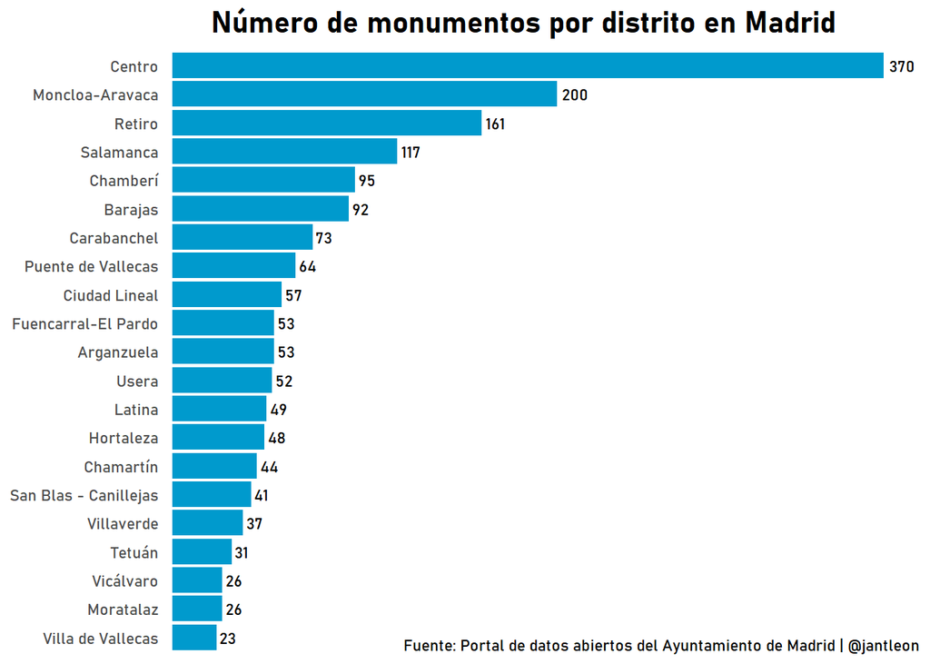

```r
monumentos %>%
  filter(!is.na(distrito) & distrito != "Distrito") %>%
  group_by(distrito) %>%
  summarize(Count=n()) %>%
  ggplot(aes(reorder(distrito, Count), Count)) +
    geom_bar(stat = "identity", fill =  "deepskyblue3") +
    geom_text(aes(label=Count, family = "Bahnschrift"), hjust=-0.2, size = 3) +
    labs(title = "Número de monumentos por distrito en Madrid ", caption = "Fuente: Portal de datos abiertos del Ayuntamiento de Madrid | @jantleon") +
    theme_day1() +
    coord_flip() +
  ggsave("plots/day1.png")
```

## Día 2: Gráfico de líneas con la evolución de las llamadas al 016 y media móvil

Empezaremos cargando los datos, que en este caso son un .csv adaptado de una tabla del [Portal Estadístico de Violencia de Género](http://estadisticasviolenciagenero.igualdad.mpr.gob.es/) del Ministerio de Igualdad. Visualizaremos la evolución temporal de las llamadas al 016, que es un teléfono un servicio telefónico de información y de asesoramiento jurídico en materia de violencia de género que existe en España desde 2007.

En este caso trataremos con fechas, que son un tipo de variable que puede dar algunos problemas. En este fragmento de código parseamos la fecha para que R pueda trabajar con ella y sepa que se trata de una variable de este tipo.

```r
data <- read_csv2("data/day2.csv")

data <- data %>%
  mutate(X2 = parse_datetime(X2, format = "%d%.%m%.%Y")) %>%
  rename(Fecha = X2, Llamadas = "Número de llamadas pertinentes")
```

Como queremos visualizar la evolución de las llamadas al 016 a lo largo del tiempo tendremos que usar un gráfico de línea. Además, para poder detectar tendencias se pintará una media móvil de 6 meses que facilita esta tarea al reducir la componente irregular de la serie y, con ello, suavizar la línea. Para este propósito utilizaremos la función “geom_ma” del paquete “tidyquant”.

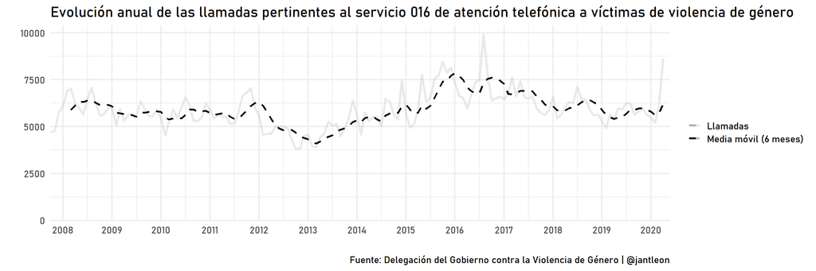

```r
library(tidyquant)

colors <- c("Llamadas" = "darkgrey", "Media móvil (6 meses)" = "black")

data %>%
  ggplot() +
  geom_line(aes(as.Date(Fecha), Llamadas, color = "Llamadas"), size = 1.5, alpha = 0.25) +
  geom_ma(aes(as.Date(Fecha), Llamadas, color = "Media móvil (6 meses)"), n = 6, size = 1.2) +
  labs(title = "Evolución anual de las llamadas pertinentes al servicio 016 de atención telefónica a víctimas de violencia de género", caption = "Fuente: Delegación del Gobierno contra la Violencia de Género | @jantleon", color = "") +
  scale_x_date(date_breaks = "1 year", date_labels = "%Y", limits = as.Date(c('2007-10-1', '2020-5-21')), expand=c(0,0)) +
  ylab("") +
  xlab("") +
  scale_color_manual(values = colors) +
  theme_minimal(base_family = "Bahnschrift", base_size = 16) +
  ggsave("try.png", width = 18)
```